# Assignment 1 - Exploratory Data Analysis

Author

Arnav Bhatia

# Introduction

This exploratory data analysis examines whether daily concentrations of fine particulate matter (PM$_{2.5}$) decreased in California between 2002 and 2022. The data were downloaded from the U.S. Environmental Protection Agency’s [EPA Air Quality Data website](https://www.epa.gov/outdoor-air-quality-data/download-daily-data). The analysis examines the data at the state, county, and Los Angeles County monitoring-site levels.

```r
library(tidyverse)
library(lubridate)
library(janitor)
library(maps)
library(knitr)

theme_set(theme_minimal())

options(
  dplyr.summarise.inform = FALSE,
  scipen = 999
)
```

# 1. Initial Data Inspection

## Read the datasets

The CSV files are stored outside the GitHub repository so the raw EPA data will not be uploaded to GitHub. On my computer, the files are stored in the Downloads folder.

```r
# Change this line if the CSV files are stored somewhere else.
data_dir <- "~/Downloads"

pm2002_raw <- read_csv(
  file.path(data_dir, "ad_viz_plotval_data (1).csv"),
  show_col_types = FALSE
)

pm2022_raw <- read_csv(
  file.path(data_dir, "ad_viz_plotval_data.csv"),
  show_col_types = FALSE
)
```

## Dimensions

```r
data_dimensions <- tibble(
  year = c(2002, 2022),
  rows = c(nrow(pm2002_raw), nrow(pm2022_raw)),
  columns = c(ncol(pm2002_raw), ncol(pm2022_raw))
)

kable(
  data_dimensions,
  caption = "Dimensions of the two EPA datasets"
)
```

Dimensions of the two EPA datasets

| year | rows | columns |
| --- | --- | --- |
| 2002 | 15976 | 22 |
| 2022 | 59918 | 22 |

The 2002 dataset contains 15,976 observations and 22 variables. The 2022 dataset contains 59,918 observations and 22 variables. Therefore, substantially more monitoring observations were available in 2022.

## Headers and footers

```r
head(pm2002_raw)
tail(pm2002_raw)

head(pm2022_raw)
tail(pm2022_raw)
```

```
# A tibble: 6 × 22
  Date     Source `Site ID`   POC Daily Mean PM2.5 Con…¹ Units `Daily AQI Value`
  <chr>    <chr>  <chr>     <dbl>                  <dbl> <chr>             <dbl>
1 01/05/2… AQS    060010007     1                   25.1 ug/m…                81
2 01/06/2… AQS    060010007     1                   31.6 ug/m…                93
3 01/08/2… AQS    060010007     1                   21.4 ug/m…                74
4 01/11/2… AQS    060010007     1                   25.9 ug/m…                82
5 01/14/2… AQS    060010007     1                   34.5 ug/m…                98
6 01/17/2… AQS    060010007     1                   41   ug/m…               115
# ℹ abbreviated name: ¹`Daily Mean PM2.5 Concentration`
# ℹ 15 more variables: `Local Site Name` <chr>, `Daily Obs Count` <dbl>,
#   `Percent Complete` <dbl>, `AQS Parameter Code` <dbl>,
#   `AQS Parameter Description` <chr>, `Method Code` <dbl>,
#   `Method Description` <chr>, `CBSA Code` <dbl>, `CBSA Name` <chr>,
#   `State FIPS Code` <chr>, State <chr>, `County FIPS Code` <chr>,
#   County <chr>, `Site Latitude` <dbl>, `Site Longitude` <dbl>
# A tibble: 6 × 22
  Date     Source `Site ID`   POC Daily Mean PM2.5 Con…¹ Units `Daily AQI Value`
  <chr>    <chr>  <chr>     <dbl>                  <dbl> <chr>             <dbl>
1 12/10/2… AQS    061131003     1                     15 ug/m…                62
2 12/13/2… AQS    061131003     1                     15 ug/m…                62
3 12/22/2… AQS    061131003     1                      1 ug/m…                 6
4 12/25/2… AQS    061131003     1                     23 ug/m…                77
5 12/28/2… AQS    061131003     1                      5 ug/m…                28
6 12/31/2… AQS    061131003     1                      6 ug/m…                33
# ℹ abbreviated name: ¹`Daily Mean PM2.5 Concentration`
# ℹ 15 more variables: `Local Site Name` <chr>, `Daily Obs Count` <dbl>,
#   `Percent Complete` <dbl>, `AQS Parameter Code` <dbl>,
#   `AQS Parameter Description` <chr>, `Method Code` <dbl>,
#   `Method Description` <chr>, `CBSA Code` <dbl>, `CBSA Name` <chr>,
#   `State FIPS Code` <chr>, State <chr>, `County FIPS Code` <chr>,
#   County <chr>, `Site Latitude` <dbl>, `Site Longitude` <dbl>
# A tibble: 6 × 22
  Date     Source `Site ID`   POC Daily Mean PM2.5 Con…¹ Units `Daily AQI Value`
  <chr>    <chr>  <chr>     <dbl>                  <dbl> <chr>             <dbl>
1 01/01/2… AQS    060010007     3                   12.7 ug/m…                58
2 01/02/2… AQS    060010007     3                   13.9 ug/m…                60
3 01/03/2… AQS    060010007     3                    7.1 ug/m…                39
4 01/04/2… AQS    060010007     3                    3.7 ug/m…                21
5 01/05/2… AQS    060010007     3                    4.2 ug/m…                23
```

[output cut: 9 more lines]

```
  Date     Source `Site ID`   POC Daily Mean PM2.5 Con…¹ Units `Daily AQI Value`
  <chr>    <chr>  <chr>     <dbl>                  <dbl> <chr>             <dbl>
1 12/01/2… AQS    061131003     1                    3.4 ug/m…                19
2 12/07/2… AQS    061131003     1                    3.8 ug/m…                21
3 12/13/2… AQS    061131003     1                    6   ug/m…                33
4 12/19/2… AQS    061131003     1                   34.8 ug/m…                99
5 12/25/2… AQS    061131003     1                   23.2 ug/m…                77
6 12/31/2… AQS    061131003     1                    1   ug/m…                 6
# ℹ abbreviated name: ¹`Daily Mean PM2.5 Concentration`
# ℹ 15 more variables: `Local Site Name` <chr>, `Daily Obs Count` <dbl>,
#   `Percent Complete` <dbl>, `AQS Parameter Code` <dbl>,
#   `AQS Parameter Description` <chr>, `Method Code` <dbl>,
#   `Method Description` <chr>, `CBSA Code` <dbl>, `CBSA Name` <chr>,
#   `State FIPS Code` <chr>, State <chr>, `County FIPS Code` <chr>,
#   County <chr>, `Site Latitude` <dbl>, `Site Longitude` <dbl>
```

The headers and footers confirm that the 2002 file begins and ends with dates from 2002, while the 2022 file begins and ends with dates from 2022. Both files contain observations from California and have the same basic structure.

## Variable names

```r
names(pm2002_raw)
```

```
 [1] "Date"                           "Source"
 [3] "Site ID"                        "POC"
 [5] "Daily Mean PM2.5 Concentration" "Units"
 [7] "Daily AQI Value"                "Local Site Name"
 [9] "Daily Obs Count"                "Percent Complete"
[11] "AQS Parameter Code"             "AQS Parameter Description"
[13] "Method Code"                    "Method Description"
[15] "CBSA Code"                      "CBSA Name"
[17] "State FIPS Code"                "State"
[19] "County FIPS Code"               "County"
[21] "Site Latitude"                  "Site Longitude"
```

```r
names(pm2022_raw)
```

```
 [1] "Date"                           "Source"
 [3] "Site ID"                        "POC"
 [5] "Daily Mean PM2.5 Concentration" "Units"
 [7] "Daily AQI Value"                "Local Site Name"
 [9] "Daily Obs Count"                "Percent Complete"
[11] "AQS Parameter Code"             "AQS Parameter Description"
[13] "Method Code"                    "Method Description"
[15] "CBSA Code"                      "CBSA Name"
[17] "State FIPS Code"                "State"
[19] "County FIPS Code"               "County"
[21] "Site Latitude"                  "Site Longitude"
```

Both datasets have the same variable names. Important variables include `Date`, `Site ID`, `Daily Mean PM2.5 Concentration`, `Local Site Name`, `County`, `Site Latitude`, and `Site Longitude`.

## Variable types

```r
glimpse(pm2002_raw)
```

```
Rows: 15,976
Columns: 22
$ Date                             <chr> "01/05/2002", "01/06/2002", "01/08/20…
$ Source                           <chr> "AQS", "AQS", "AQS", "AQS", "AQS", "A…
$ `Site ID`                        <chr> "060010007", "060010007", "060010007"…
$ POC                              <dbl> 1, 1, 1, 1, 1, 1, 1, 1, 1, 1, 1, 1, 1…
$ `Daily Mean PM2.5 Concentration` <dbl> 25.1, 31.6, 21.4, 25.9, 34.5, 41.0, 2…
$ Units                            <chr> "ug/m3 LC", "ug/m3 LC", "ug/m3 LC", "…
$ `Daily AQI Value`                <dbl> 81, 93, 74, 82, 98, 115, 89, 62, 69, …
$ `Local Site Name`                <chr> "Livermore", "Livermore", "Livermore"…
$ `Daily Obs Count`                <dbl> 1, 1, 1, 1, 1, 1, 1, 1, 1, 1, 1, 1, 1…
$ `Percent Complete`               <dbl> 100, 100, 100, 100, 100, 100, 100, 10…
$ `AQS Parameter Code`             <dbl> 88101, 88101, 88101, 88101, 88101, 88…
$ `AQS Parameter Description`      <chr> "PM2.5 - Local Conditions", "PM2.5 - …
$ `Method Code`                    <dbl> 120, 120, 120, 120, 120, 120, 120, 12…
$ `Method Description`             <chr> "Andersen RAAS2.5-300 PM2.5 SEQ w/WIN…
$ `CBSA Code`                      <dbl> 41860, 41860, 41860, 41860, 41860, 41…
$ `CBSA Name`                      <chr> "San Francisco-Oakland-Hayward, CA", …
$ `State FIPS Code`                <chr> "06", "06", "06", "06", "06", "06", "…
$ State                            <chr> "California", "California", "Californ…
$ `County FIPS Code`               <chr> "001", "001", "001", "001", "001", "0…
$ County                           <chr> "Alameda", "Alameda", "Alameda", "Ala…
$ `Site Latitude`                  <dbl> 37.68753, 37.68753, 37.68753, 37.6875…
$ `Site Longitude`                 <dbl> -121.7842, -121.7842, -121.7842, -121…
```

```r
glimpse(pm2022_raw)
```

```
Rows: 59,918
Columns: 22
$ Date                             <chr> "01/01/2022", "01/02/2022", "01/03/20…
$ Source                           <chr> "AQS", "AQS", "AQS", "AQS", "AQS", "A…
$ `Site ID`                        <chr> "060010007", "060010007", "060010007"…
$ POC                              <dbl> 3, 3, 3, 3, 3, 3, 3, 3, 3, 3, 3, 3, 3…
$ `Daily Mean PM2.5 Concentration` <dbl> 12.7, 13.9, 7.1, 3.7, 4.2, 3.8, 2.3, …
$ Units                            <chr> "ug/m3 LC", "ug/m3 LC", "ug/m3 LC", "…
$ `Daily AQI Value`                <dbl> 58, 60, 39, 21, 23, 21, 13, 38, 59, 5…
$ `Local Site Name`                <chr> "Livermore", "Livermore", "Livermore"…
$ `Daily Obs Count`                <dbl> 1, 1, 1, 1, 1, 1, 1, 1, 1, 1, 1, 1, 1…
$ `Percent Complete`               <dbl> 100, 100, 100, 100, 100, 100, 100, 10…
$ `AQS Parameter Code`             <dbl> 88101, 88101, 88101, 88101, 88101, 88…
$ `AQS Parameter Description`      <chr> "PM2.5 - Local Conditions", "PM2.5 - …
$ `Method Code`                    <dbl> 170, 170, 170, 170, 170, 170, 170, 17…
$ `Method Description`             <chr> "Met One BAM-1020 Mass Monitor w/VSCC…
$ `CBSA Code`                      <dbl> 41860, 41860, 41860, 41860, 41860, 41…
$ `CBSA Name`                      <chr> "San Francisco-Oakland-Hayward, CA", …
$ `State FIPS Code`                <chr> "06", "06", "06", "06", "06", "06", "…
$ State                            <chr> "California", "California", "Californ…
$ `County FIPS Code`               <chr> "001", "001", "001", "001", "001", "0…
$ County                           <chr> "Alameda", "Alameda", "Alameda", "Ala…
$ `Site Latitude`                  <dbl> 37.68753, 37.68753, 37.68753, 37.6875…
$ `Site Longitude`                 <dbl> -121.7842, -121.7842, -121.7842, -121…
```

Most identification and location variables were read as character variables, while PM$_{2.5}$, latitude, and longitude were read as numeric variables. The `Date` variable was initially read as a character variable and will be converted to a proper date in the next section.

## Distribution of PM2.5

```r
pm_distribution_raw <- bind_rows(
  pm2002_raw |> mutate(dataset_year = 2002),
  pm2022_raw |> mutate(dataset_year = 2022)
) |>
  transmute(
    year = factor(dataset_year),
    pm25 = `Daily Mean PM2.5 Concentration`
  )

pm_distribution_raw |>
  group_by(year) |>
  summarise(
    n = n(),
    missing = sum(is.na(pm25)),
    minimum = min(pm25, na.rm = TRUE),
    first_quartile = quantile(pm25, 0.25, na.rm = TRUE),
    median = median(pm25, na.rm = TRUE),
    mean = mean(pm25, na.rm = TRUE),
    third_quartile = quantile(pm25, 0.75, na.rm = TRUE),
    maximum = max(pm25, na.rm = TRUE)
  ) |>
  kable(
    digits = 2,
    caption = "Initial summary of daily PM2.5 concentrations"
  )
```

Initial summary of daily PM2.5 concentrations

| year | n | missing | minimum | first_quartile | median | mean | third_quartile | maximum |
| --- | --- | --- | --- | --- | --- | --- | --- | --- |
| 2002 | 15976 | 0 | 0.0 | 7.0 | 12.0 | 16.12 | 20.5 | 104.3 |
| 2022 | 59918 | 0 | -6.7 | 4.1 | 6.8 | 8.41 | 10.7 | 302.5 |

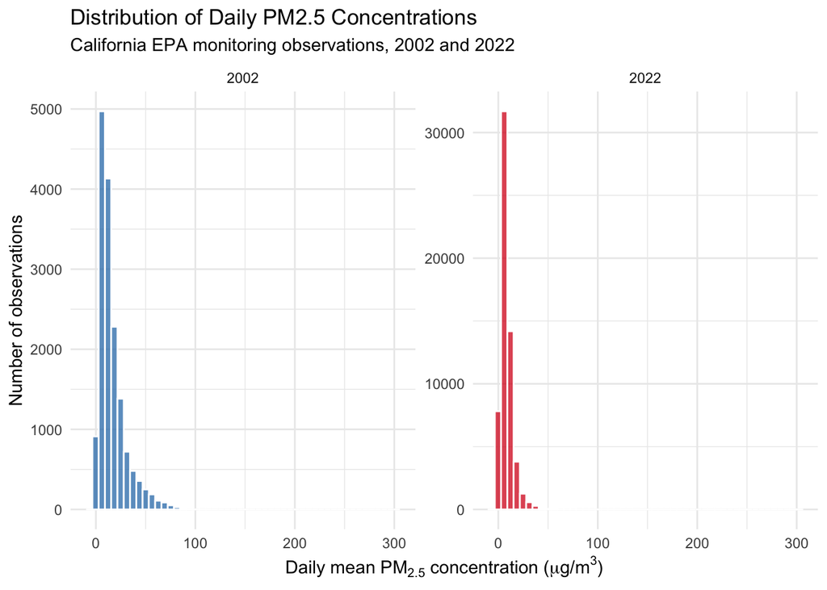

```r
ggplot(
  pm_distribution_raw,
  aes(x = pm25, fill = year)
) +
  geom_histogram(
    bins = 50,
    color = "white",
    alpha = 0.75
  ) +
  facet_wrap(
    vars(year),
    scales = "free_y"
  ) +
  scale_fill_manual(
    values = c("2002" = "#2C7BB6", "2022" = "#D7191C")
  ) +
  labs(
    title = "Distribution of Daily PM2.5 Concentrations",
    subtitle = "California EPA monitoring observations, 2002 and 2022",
    x = expression("Daily mean PM"[2.5] * " concentration (" * mu * "g/m"^3 * ")"),
    y = "Number of observations",
    fill = "Year"
  ) +
  guides(fill = "none")
```

The distributions are right-skewed in both years, meaning that most daily concentrations are relatively low but a smaller number of days have very high concentrations. The 2022 data include negative values, which are not physically plausible concentrations and will be addressed during the data-quality check. The high positive observations may reflect genuine extreme pollution episodes, including wildfire smoke, so they are retained unless there is additional evidence that they are errors.

# 2. Combine and Clean the Data

The two datasets were combined using `bind_rows()`. The variable names were standardized with `clean_names()`, and the key variables were given shorter names. The year identifier was derived from the date rather than from the dataset name.

```r
pm_combined <- bind_rows(pm2002_raw, pm2022_raw) |>
  clean_names() |>
  transmute(
    date = mdy(date),
    year = year(date),
    pm25 = daily_mean_pm2_5_concentration,
    site_id = as.character(site_id),
    poc = as.character(poc),
    site_name = local_site_name,
    county,
    latitude = site_latitude,
    longitude = site_longitude,
    parameter_code = as.character(aqs_parameter_code),
    parameter_description = aqs_parameter_description,
    method_code = as.character(method_code),
    method_description
  )
```

```r
glimpse(pm_combined)
```

```
Rows: 75,894
Columns: 13
$ date                  <date> 2002-01-05, 2002-01-06, 2002-01-08, 2002-01-11,…
$ year                  <dbl> 2002, 2002, 2002, 2002, 2002, 2002, 2002, 2002, …
$ pm25                  <dbl> 25.1, 31.6, 21.4, 25.9, 34.5, 41.0, 29.3, 15.0, …
$ site_id               <chr> "060010007", "060010007", "060010007", "06001000…
$ poc                   <chr> "1", "1", "1", "1", "1", "1", "1", "1", "1", "1"…
$ site_name             <chr> "Livermore", "Livermore", "Livermore", "Livermor…
$ county                <chr> "Alameda", "Alameda", "Alameda", "Alameda", "Ala…
$ latitude              <dbl> 37.68753, 37.68753, 37.68753, 37.68753, 37.68753…
$ longitude             <dbl> -121.7842, -121.7842, -121.7842, -121.7842, -121…
$ parameter_code        <chr> "88101", "88101", "88101", "88101", "88101", "88…
$ parameter_description <chr> "PM2.5 - Local Conditions", "PM2.5 - Local Condi…
$ method_code           <chr> "120", "120", "120", "120", "120", "120", "120",…
$ method_description    <chr> "Andersen RAAS2.5-300 PM2.5 SEQ w/WINS", "Anders…
```

```r
pm_combined |>
  count(year, name = "number_of_rows") |>
  kable(
    caption = "Number of observations after combining the datasets"
  )
```

Number of observations after combining the datasets

| year | number_of_rows |
| --- | --- |
| 2002 | 15976 |
| 2022 | 59918 |

The combined dataset contains observations from both years. The renamed variables make the subsequent code shorter and easier to interpret.

Some sites have more than one measurement for the same date because the EPA files include different parameter codes, instruments, or pollutant occurrence codes. For the state, county, and site comparisons, these repeated measurements are averaged to create one PM$_{2.5}$ value per site per day. This prevents site-days with several instruments from receiving more weight than site-days with only one measurement.

# 3. Spatial Distribution of Monitoring Sites

First, one record was retained for every unique monitoring site in each year.

```r
monitoring_sites <- pm_combined |>
  distinct(
    year,
    site_id,
    site_name,
    county,
    latitude,
    longitude
  )
```

```r
monitoring_sites |>
  count(year, name = "number_of_sites") |>
  kable(
    caption = "Number of California monitoring sites by year"
  )
```

Number of California monitoring sites by year

| year | number_of_sites |
| --- | --- |
| 2002 | 103 |
| 2022 | 167 |

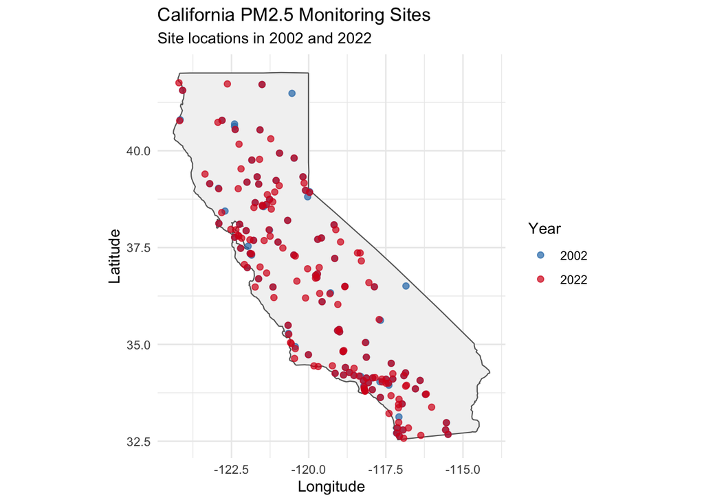

```r
california_map <- map_data("state") |>
  filter(region == "california")

ggplot() +
  geom_polygon(
    data = california_map,
    aes(x = long, y = lat, group = group),
    fill = "gray95",
    color = "gray40",
    linewidth = 0.4
  ) +
  geom_point(
    data = monitoring_sites,
    aes(
      x = longitude,
      y = latitude,
      color = factor(year)
    ),
    alpha = 0.70,
    size = 1.8
  ) +
  coord_quickmap() +
  scale_color_manual(
    values = c("2002" = "#2C7BB6", "2022" = "#D7191C")
  ) +
  labs(
    title = "California PM2.5 Monitoring Sites",
    subtitle = "Site locations in 2002 and 2022",
    x = "Longitude",
    y = "Latitude",
    color = "Year"
  )
```

There were 103 monitoring sites in 2002 and 167 sites in 2022. In both years, monitoring sites were concentrated around major population centers, including the Los Angeles region, the San Francisco Bay Area, the Central Valley, and the San Diego region. The 2022 network included more sites and provided broader coverage than the 2002 network. Nevertheless, the sites were not distributed uniformly across California; rural and sparsely populated areas generally had fewer monitors.

# 4. Missing and Implausible PM2.5 Values

A negative PM$_{2.5}$ concentration was classified as implausible because a physical concentration cannot be below zero. Zero was retained as a possible very low measurement. High positive values were also retained because major air-pollution and wildfire events can produce extremely high concentrations.

```r
data_quality <- pm_combined |>
  mutate(
    missing_pm25 = is.na(pm25),
    implausible_pm25 = !is.na(pm25) & pm25 < 0,
    missing_or_implausible = missing_pm25 | implausible_pm25
  ) |>
  group_by(year) |>
  summarise(
    total_observations = n(),
    missing_n = sum(missing_pm25),
    missing_proportion = mean(missing_pm25),
    implausible_n = sum(implausible_pm25),
    implausible_proportion = mean(implausible_pm25),
    affected_n = sum(missing_or_implausible),
    affected_proportion = mean(missing_or_implausible)
  )

data_quality |>
  mutate(
    missing_proportion = scales::percent(
      missing_proportion,
      accuracy = 0.01
    ),
    implausible_proportion = scales::percent(
      implausible_proportion,
      accuracy = 0.01
    ),
    affected_proportion = scales::percent(
      affected_proportion,
      accuracy = 0.01
    )
  ) |>
  kable(
    caption = "Missing and implausible PM2.5 observations by year"
  )
```

Missing and implausible PM2.5 observations by year

| year | total_observations | missing_n | missing_proportion | implausible_n | implausible_proportion | affected_n | affected_proportion |
| --- | --- | --- | --- | --- | --- | --- | --- |
| 2002 | 15976 | 0 | 0.00% | 0 | 0.00% | 0 | 0.00% |
| 2022 | 59918 | 0 | 0.00% | 215 | 0.36% | 215 | 0.36% |

There were no missing PM$_{2.5}$ values in either dataset. There were no negative values in 2002, but the 2022 dataset contained 215 negative values. Thus, the identified implausible-value problem was limited to 2022, although it affected only a small proportion of that year’s observations.

The implausible values were changed to missing before conducting the main comparisons.

```r
pm_clean <- pm_combined |>
  mutate(
    pm25_clean = if_else(pm25 < 0, NA_real_, pm25)
  )
```

A site-day dataset was then created by averaging valid measurements recorded at the same site on the same date.

```r
site_day <- pm_clean |>
  group_by(
    year,
    date,
    site_id,
    site_name,
    county,
    latitude,
    longitude
  ) |>
  summarise(
    pm25 = if (
      all(is.na(pm25_clean))
    ) {
      NA_real_
    } else {
      mean(pm25_clean, na.rm = TRUE)
    },
    number_of_measurements = n(),
    .groups = "drop"
  )
```

# 5. PM2.5 at Three Spatial Levels

## Level 1: State

The statewide comparison uses one observation per monitoring site per day.

```r
state_summary <- site_day |>
  group_by(year) |>
  summarise(
    site_days = n(),
    valid_site_days = sum(!is.na(pm25)),
    mean_pm25 = mean(pm25, na.rm = TRUE),
    standard_deviation = sd(pm25, na.rm = TRUE),
    minimum = min(pm25, na.rm = TRUE),
    first_quartile = quantile(pm25, 0.25, na.rm = TRUE),
    median_pm25 = median(pm25, na.rm = TRUE),
    third_quartile = quantile(pm25, 0.75, na.rm = TRUE),
    maximum = max(pm25, na.rm = TRUE)
  )

state_summary |>
  kable(
    digits = 2,
    caption = "Statewide summary of daily PM2.5 concentrations"
  )
```

Statewide summary of daily PM2.5 concentrations

| year | site_days | valid_site_days | mean_pm25 | standard_deviation | minimum | first_quartile | median_pm25 | third_quartile | maximum |
| --- | --- | --- | --- | --- | --- | --- | --- | --- | --- |
| 2002 | 13348 | 13348 | 15.22 | 12.95 | 0 | 6.5 | 11.5 | 19.40 | 98.17 |
| 2022 | 49057 | 48858 | 8.30 | 7.78 | 0 | 4.0 | 6.7 | 10.45 | 302.50 |

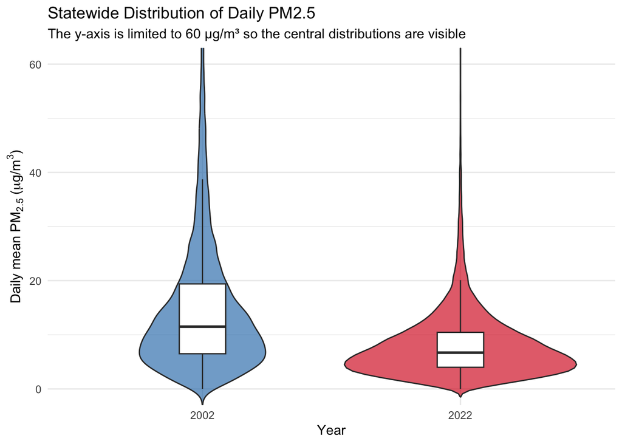

```r
ggplot(
  site_day,
  aes(
    x = factor(year),
    y = pm25,
    fill = factor(year)
  )
) +
  geom_violin(
    trim = FALSE,
    alpha = 0.65,
    na.rm = TRUE
  ) +
  geom_boxplot(
    width = 0.18,
    outlier.shape = NA,
    fill = "white",
    na.rm = TRUE
  ) +
  coord_cartesian(ylim = c(0, 60)) +
  scale_fill_manual(
    values = c("2002" = "#2C7BB6", "2022" = "#D7191C")
  ) +
  labs(
    title = "Statewide Distribution of Daily PM2.5",
    subtitle = "The y-axis is limited to 60 µg/m³ so the central distributions are visible",
    x = "Year",
    y = expression("Daily mean PM"[2.5] * " (" * mu * "g/m"^3 * ")")
  ) +
  guides(fill = "none")
```

The statewide mean decreased from 15.2 µg/m³ in 2002 to 8.3 µg/m³ in 2022. The median decreased from 11.5 µg/m³ to 6.7 µg/m³. The lower mean and median in 2022 provide descriptive evidence that typical daily PM$_{2.5}$ concentrations decreased statewide. However, both years contain high-pollution observations, and the maximum alone should not be used to describe the typical exposure level.

## Level 2: County

County-level summary statistics were calculated separately for every county and year.

```r
county_summary <- site_day |>
  group_by(county, year) |>
  summarise(
    number_of_sites = n_distinct(site_id),
    site_days = n(),
    valid_site_days = sum(!is.na(pm25)),
    mean_pm25 = mean(pm25, na.rm = TRUE),
    median_pm25 = median(pm25, na.rm = TRUE),
    standard_deviation = sd(pm25, na.rm = TRUE),
    first_quartile = quantile(pm25, 0.25, na.rm = TRUE),
    third_quartile = quantile(pm25, 0.75, na.rm = TRUE)
  ) |>
  arrange(county, year)

county_summary |>
  kable(
    digits = 2,
    caption = "County-level PM2.5 summary statistics"
  )
```

County-level PM2.5 summary statistics

| county | year | number_of_sites | site_days | valid_site_days | mean_pm25 | median_pm25 | standard_deviation | first_quartile | third_quartile |
| --- | --- | --- | --- | --- | --- | --- | --- | --- | --- |
| Alameda | 2002 | 2 | 191 | 191 | 14.00 | 9.90 | 11.24 | 6.70 | 16.20 |
| Alameda | 2022 | 5 | 1793 | 1790 | 8.21 | 7.00 | 4.95 | 4.70 | 10.50 |
| Butte | 2002 | 2 | 418 | 418 | 14.68 | 11.60 | 11.18 | 7.62 | 17.88 |
| Butte | 2022 | 3 | 1066 | 1054 | 6.14 | 4.50 | 5.70 | 2.60 | 7.50 |
| Calaveras | 2002 | 1 | 60 | 60 | 9.90 | 8.00 | 6.50 | 6.00 | 12.25 |
| Calaveras | 2022 | 1 | 355 | 355 | 6.04 | 5.00 | 4.10 | 3.20 | 7.35 |
| Colusa | 2002 | 1 | 95 | 95 | 11.73 | 9.00 | 10.01 | 5.00 | 14.50 |
| Colusa | 2022 | 2 | 401 | 401 | 7.61 | 6.70 | 4.76 | 4.10 | 10.20 |
| Contra Costa | 2002 | 1 | 204 | 204 | 14.92 | 9.60 | 14.12 | 6.57 | 16.41 |
| Contra Costa | 2022 | 2 | 709 | 709 | 8.41 | 7.60 | 4.88 | 5.00 | 10.60 |
| Del Norte | 2002 | 1 | 110 | 110 | 3.82 | 3.45 | 2.56 | 1.90 | 5.65 |
| Del Norte | 2022 | 2 | 458 | 452 | 5.04 | 4.30 | 3.55 | 2.40 | 6.80 |
| El Dorado | 2002 | 3 | 179 | 179 | 4.62 | 3.60 | 4.02 | 1.75 | 6.00 |
| El Dorado | 2022 | 2 | 228 | 228 | 4.07 | 2.70 | 9.18 | 1.30 | 3.90 |
| Fresno | 2002 | 4 | 593 | 593 | 19.09 | 12.10 | 18.23 | 7.00 | 23.50 |
| Fresno | 2022 | 8 | 2572 | 2569 | 10.12 | 7.60 | 8.31 | 4.70 | 12.50 |
| Glenn | 2022 | 1 | 351 | 335 | 5.62 | 4.60 | 4.92 | 2.20 | 7.50 |
| Humboldt | 2002 | 1 | 59 | 59 | 7.79 | 6.80 | 4.59 | 5.00 | 9.25 |
| Humboldt | 2022 | 1 | 116 | 116 | 6.76 | 5.70 | 4.35 | 3.98 | 7.73 |
| Imperial | 2002 | 3 | 298 | 298 | 12.33 | 10.75 | 7.62 | 7.70 | 14.40 |
| Imperial | 2022 | 4 | 1298 | 1297 | 9.51 | 8.30 | 6.18 | 5.80 | 11.20 |
| Inyo | 2002 | 2 | 223 | 223 | 6.81 | 4.30 | 9.18 | 2.55 | 7.00 |
| Inyo | 2022 | 5 | 1690 | 1690 | 5.63 | 4.15 | 5.46 | 2.95 | 5.99 |
| Kern | 2002 | 6 | 867 | 867 | 19.62 | 13.60 | 17.83 | 7.84 | 23.30 |
| Kern | 2022 | 7 | 1982 | 1964 | 9.04 | 6.20 | 9.28 | 3.44 | 10.60 |
| Kings | 2002 | 1 | 83 | 83 | 24.70 | 18.00 | 19.06 | 10.10 | 31.95 |
| Kings | 2022 | 2 | 721 | 721 | 14.40 | 10.60 | 10.78 | 6.90 | 18.50 |
| Lake | 2002 | 1 | 61 | 61 | 6.50 | 4.00 | 10.88 | 2.70 | 6.00 |
| Lake | 2022 | 1 | 61 | 61 | 4.26 | 3.80 | 3.12 | 2.40 | 5.00 |
| Los Angeles | 2002 | 10 | 1844 | 1844 | 19.60 | 17.30 | 11.94 | 11.00 | 25.50 |

[output cut: 68 more lines]

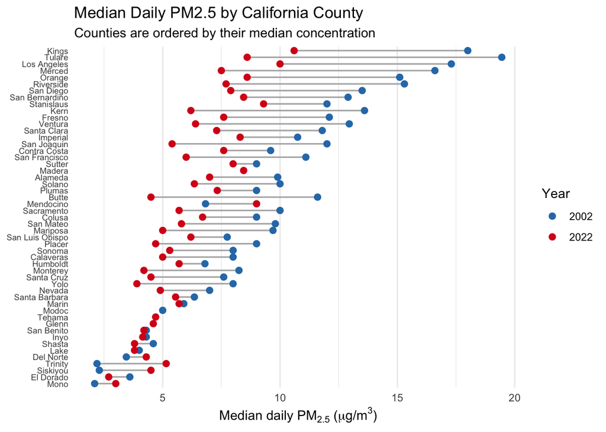

```r
county_order <- county_summary |>
  group_by(county) |>
  summarise(overall_median = median(median_pm25, na.rm = TRUE)) |>
  arrange(overall_median) |>
  pull(county)

county_summary <- county_summary |>
  mutate(
    county = factor(county, levels = county_order)
  )

ggplot(
  county_summary,
  aes(
    x = median_pm25,
    y = county,
    color = factor(year),
    group = county
  )
) +
  geom_line(
    color = "gray70",
    linewidth = 0.6
  ) +
  geom_point(size = 2.2) +
  scale_color_manual(
    values = c("2002" = "#2C7BB6", "2022" = "#D7191C")
  ) +
  labs(
    title = "Median Daily PM2.5 by California County",
    subtitle = "Counties are ordered by their median concentration",
    x = expression("Median daily PM"[2.5] * " (" * mu * "g/m"^3 * ")"),
    y = NULL,
    color = "Year"
  ) +
  theme(
    panel.grid.major.y = element_blank(),
    axis.text.y = element_text(size = 7)
  )
```

The plot shows that the amount of change varied across counties. For counties with data in both years, a 2022 point located to the left of its 2002 point indicates a reduction in the median daily concentration. Many counties show lower median PM$_{2.5}$ concentrations in 2022, although the magnitude of the decrease is not identical across the state. Counties represented in only one year cannot be used for a direct temporal comparison.

The number of counties represented also changed from 48 in 2002 to 50 in 2022. Therefore, county comparisons should be interpreted with awareness that the monitoring network changed over time.

## Level 3: Monitoring Sites in Los Angeles County

The final analysis was restricted to monitoring sites located in Los Angeles County.

```r
la_site_day <- site_day |>
  filter(county == "Los Angeles") |>
  mutate(
    site_label = if_else(
      is.na(site_name) | site_name == "",
      site_id,
      paste0(site_name, " (", site_id, ")")
    )
  )
```

```r
la_site_summary <- la_site_day |>
  group_by(site_id, site_name, year) |>
  summarise(
    site_days = n(),
    valid_site_days = sum(!is.na(pm25)),
    mean_pm25 = mean(pm25, na.rm = TRUE),
    median_pm25 = median(pm25, na.rm = TRUE),
    standard_deviation = sd(pm25, na.rm = TRUE),
    minimum = min(pm25, na.rm = TRUE),
    maximum = max(pm25, na.rm = TRUE)
  ) |>
  arrange(site_name, site_id, year)

la_site_summary |>
  kable(
    digits = 2,
    caption = "PM2.5 summary statistics for Los Angeles County monitoring sites"
  )
```

PM2.5 summary statistics for Los Angeles County monitoring sites

| site_id | site_name | year | site_days | valid_site_days | mean_pm25 | median_pm25 | standard_deviation | minimum | maximum |
| --- | --- | --- | --- | --- | --- | --- | --- | --- | --- |
| 060370002 | Azusa | 2002 | 339 | 339 | 20.76 | 18.70 | 12.11 | 3.10 | 72.40 |
| 060370002 | Azusa | 2022 | 76 | 76 | 9.72 | 9.65 | 4.39 | 3.10 | 18.40 |
| 060371002 | Burbank | 2002 | 122 | 122 | 23.97 | 21.65 | 12.74 | 3.50 | 63.00 |
| 060371302 | Compton | 2022 | 365 | 365 | 13.05 | 12.05 | 6.18 | 3.10 | 53.70 |
| 060370016 | Glendora | 2022 | 365 | 362 | 8.50 | 7.90 | 5.43 | 0.00 | 56.00 |
| 060379033 | Lancaster-Division Street | 2002 | 107 | 107 | 10.38 | 10.00 | 4.47 | 1.00 | 24.00 |
| 060379033 | Lancaster-Division Street | 2022 | 348 | 348 | 7.52 | 7.30 | 2.48 | 1.90 | 15.10 |
| 060379034 | Lebec | 2002 | 109 | 109 | 4.82 | 4.80 | 2.78 | 0.60 | 12.40 |
| 060379034 | Lebec | 2022 | 41 | 41 | 3.50 | 3.40 | 1.65 | 0.90 | 7.30 |
| 060374002 | Long Beach (North) | 2002 | 356 | 356 | 19.47 | 16.85 | 10.39 | 4.60 | 62.70 |
| 060374002 | Long Beach (North) | 2022 | 55 | 55 | 9.92 | 9.60 | 3.27 | 4.20 | 20.00 |
| 060374004 | Long Beach (South) | 2022 | 120 | 120 | 11.96 | 11.35 | 4.09 | 3.75 | 26.35 |
| 060374008 | Long Beach-Route 710 Near Road | 2022 | 364 | 364 | 12.49 | 11.75 | 5.21 | 2.95 | 40.35 |
| 060371103 | Los Angeles-North Main Street | 2002 | 330 | 330 | 21.89 | 19.00 | 12.02 | 3.90 | 66.30 |
| 060371103 | Los Angeles-North Main Street | 2022 | 365 | 365 | 11.60 | 11.05 | 4.40 | 2.80 | 34.80 |
| 060371301 | Lynwood | 2002 | 122 | 122 | 23.35 | 19.85 | 11.96 | 5.40 | 64.00 |
| 060374010 | North Hollywood (NOHO) | 2022 | 365 | 365 | 13.02 | 13.10 | 4.75 | 1.70 | 43.40 |
| 060372005 | Pasadena | 2002 | 121 | 121 | 20.29 | 17.80 | 11.14 | 4.00 | 57.80 |
| 060372005 | Pasadena | 2022 | 120 | 120 | 9.09 | 7.90 | 3.68 | 3.50 | 22.10 |
| 060371602 | Pico Rivera #2 | 2022 | 115 | 115 | 11.32 | 10.00 | 5.81 | 3.20 | 53.80 |
| 060371201 | Reseda | 2002 | 120 | 120 | 18.85 | 17.05 | 10.65 | 3.00 | 48.80 |
| 060371201 | Reseda | 2022 | 362 | 362 | 10.95 | 10.53 | 4.54 | 0.50 | 28.10 |
| 060376012 | Santa Clarita | 2022 | 365 | 365 | 9.14 | 8.50 | 3.90 | 2.50 | 27.20 |
| 060374009 | Signal Hill (LBSH) | 2022 | 271 | 269 | 8.82 | 8.50 | 4.27 | 0.00 | 26.70 |
| 060371601 | NA | 2002 | 118 | 118 | 23.89 | 21.45 | 12.26 | 5.60 | 61.00 |

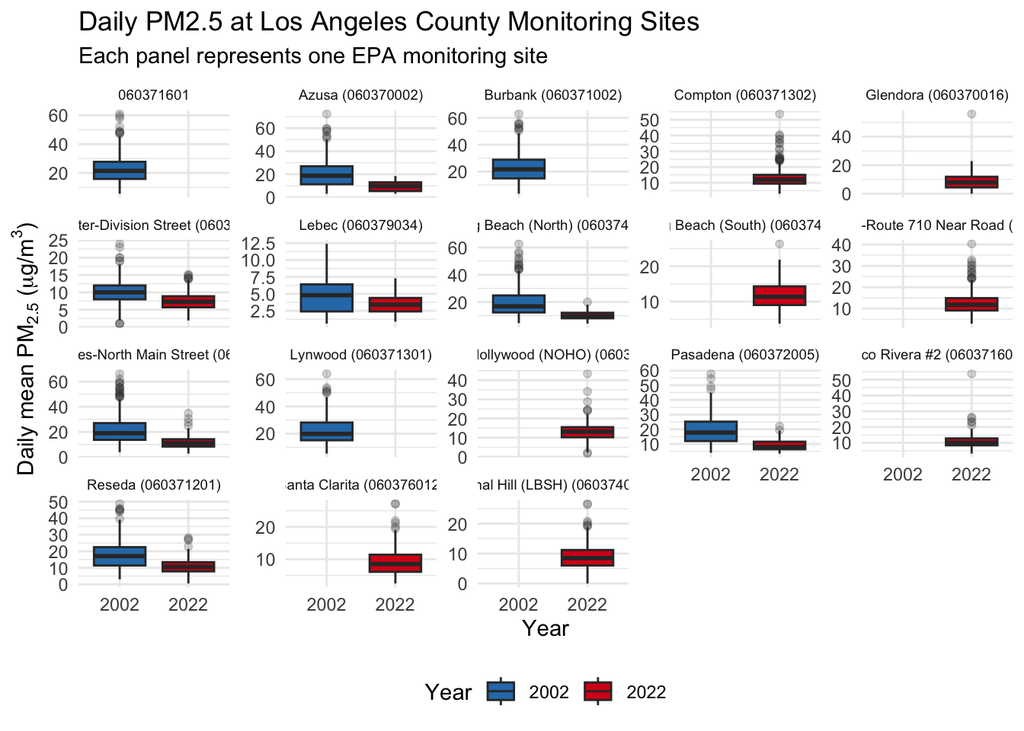

```r
ggplot(
  la_site_day,
  aes(
    x = factor(year),
    y = pm25,
    fill = factor(year)
  )
) +
  geom_boxplot(
    outlier.alpha = 0.20,
    na.rm = TRUE
  ) +
  facet_wrap(
    vars(site_label),
    scales = "free_y"
  ) +
  scale_fill_manual(
    values = c("2002" = "#2C7BB6", "2022" = "#D7191C")
  ) +
  labs(
    title = "Daily PM2.5 at Los Angeles County Monitoring Sites",
    subtitle = "Each panel represents one EPA monitoring site",
    x = "Year",
    y = expression("Daily mean PM"[2.5] * " (" * mu * "g/m"^3 * ")"),
    fill = "Year"
  ) +
  theme(
    strip.text = element_text(size = 7),
    legend.position = "bottom"
  )
```

The Los Angeles County results demonstrate that pollution levels and temporal changes were not uniform across monitoring sites. Sites with observations in both years generally allow the clearest direct comparison. Several sites show lower central concentrations in 2022, but some sites were added, removed, or relocated between the two years. Consequently, changes in the set of active monitors must be considered when interpreting the Los Angeles County results.

# Conclusion

The exploratory results indicate that typical daily PM$_{2.5}$ concentrations in California were lower in 2022 than in 2002. This pattern is visible in the statewide mean and median and across many counties and Los Angeles County monitoring sites. However, the monitoring network expanded and changed during the 20-year period, so the two datasets do not represent exactly the same set of locations.

The analysis also identified negative PM$_{2.5}$ observations in 2022. These values were classified as implausible and excluded from the concentration summaries. High positive values were retained because they may represent real extreme pollution events. Overall, the results support the conclusion that typical PM$_{2.5}$ concentrations decreased, while also showing meaningful spatial variation and occasional extreme pollution episodes.